#### Patrick Mugisha, "On my honor, as a student, I have neither given nor received unauthorized aid on this academic work."

# What statistical techniques are available?

[figure not shown]

# Differences?

### Goals

- how to perform t-testing & ANOVA
- t-testing is used to find if there is any statically significant difference in the mean values of two samples
- help to answer many questions such as:
  - any difference in intelligence scores between male and female
  - any difference in cheating on spouse between religous people and people with no religion
  - any difference in profits between small-size models and luxurious hotels

### Python packages

- Scipy
- Statsmodels
- pingouin

### Install pingouin (a new python package for statistical inference testing)

```python
# install pingouin https://pingouin-stats.org/

!pip install pingouin

#or

#!pip install pingouin --user
```

```python
import pingouin as pg
import numpy as np
import matplotlib.pyplot as plt
%matplotlib inline
import pandas as pd
from IPython.display import Image
```

### Assumptions of statistical tests

- Many statistical tests assume that the data is normally distributed (parametric data): can be tested using **stats.normaltest**
- Equal variances between different samples (homogeneity of variance): can be tested using **stats.levene**

#### Parametric data looks like this

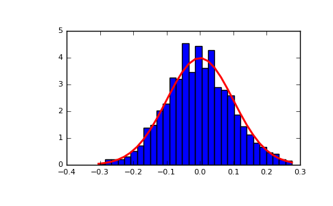

```python
# looks nornally distributed ... "parametric data"
Image("images/numpy-random-normal.png")
```

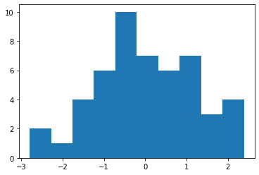

```python
# what does the parametric data look like

np.random.seed(123)   # simulated data
x = np.random.normal(size=50)
plt.hist(x)
#pg.qqplot(x, dist='norm');
```

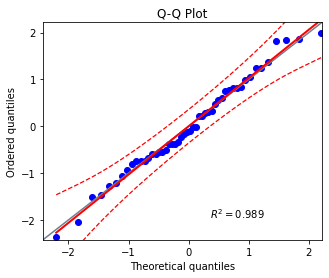

```python
pg.qqplot(x, dist='norm');
```

#### Non-parametric data looks like this

```python
# looks skewed ... "non-parametric data"
Image(url= "http://www.philender.com/courses/intro/notes3/cheby2.png")
```

[figure not shown]

### Loading python packages

```python
import pandas as pd
import numpy as np
from scipy import stats
import matplotlib.pyplot as plt
%matplotlib inline

# import the scatter_matrix functionality
from pandas.plotting import scatter_matrix

import pingouin as pg

import warnings
warnings.simplefilter(action='ignore', category=FutureWarning)
```

```python
import warnings
warnings.filterwarnings("ignore", category=FutureWarning)
```

### Loading data

```python
from pingouin import read_dataset

df = pg.read_dataset('anova')    # this is a toy dataset
df.head()
```

|  | Subject | Hair color | Pain threshold |
| --- | --- | --- | --- |
| 0 | 1 | Light Blond | 62 |
| 1 | 2 | Light Blond | 60 |
| 2 | 3 | Light Blond | 71 |
| 3 | 4 | Light Blond | 55 |
| 4 | 5 | Light Blond | 48 |

```python
df.info()
```

```
<class 'pandas.core.frame.DataFrame'>
RangeIndex: 19 entries, 0 to 18
Data columns (total 3 columns):
 #   Column          Non-Null Count  Dtype
---  ------          --------------  -----
 0   Subject         19 non-null     int64
 1   Hair color      19 non-null     object
 2   Pain threshold  19 non-null     int64
dtypes: int64(2), object(1)
memory usage: 584.0+ bytes
```

```python
df.columns = df.columns.str.replace(' ','')
df.columns = df.columns.str.lower()
df.columns
```

```
Index(['subject', 'haircolor', 'painthreshold'], dtype='object')
```

### Exploring data & Data visualization

```python
# basic stats
df.describe()
```

|  | subject | painthreshold |
| --- | --- | --- |
| count | 19.000000 | 19.000000 |
| mean | 10.000000 | 47.842105 |
| std | 5.627314 | 11.456503 |
| min | 1.000000 | 30.000000 |
| 25% | 5.500000 | 40.000000 |
| 50% | 10.000000 | 48.000000 |
| 75% | 14.500000 | 56.000000 |
| max | 19.000000 | 71.000000 |

```python
df['haircolor'].value_counts()
```

```
Dark Blond        5
Light Blond       5
Dark Brunette     5
Light Brunette    4
Name: haircolor, dtype: int64
```

```python
# pivot for haircolor
df.groupby('haircolor').mean()
```

| haircolor | subject | painthreshold |
| --- | --- | --- |
| Dark Blond | 8.0 | 51.2 |
| Dark Brunette | 17.0 | 37.4 |
| Light Blond | 3.0 | 59.2 |
| Light Brunette | 12.5 | 42.5 |

```python
df.boxplot('painthreshold', by='haircolor')
```

[output not shown]

# Check assumptions

### Normality test

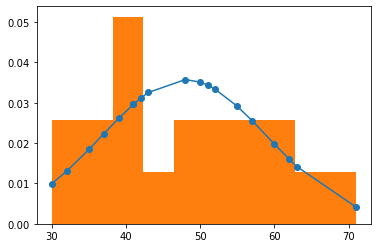

```python
# an illustration of normal distribution

h = sorted(df['painthreshold'])
fit = stats.norm.pdf(h, np.mean(h), np.std(h))  #this is a fitting indeed
plt.plot(h,fit,'-o');
plt.hist(h, density=True);      #use this to draw histogram of your data
```

```python
# test if the data is normally distributed

import scipy.stats as stats

print(stats.normaltest(df['painthreshold']))
```

```
NormaltestResult(statistic=0.8897709853074605, pvalue=0.6408976593209752)
```

```python
# to print three decimals only
pain = stats.normaltest(df['painthreshold'])
print("The chi-square statistic is %.3f and the p-value is %.3f." % pain)
```

```
The chi-square statistic is 0.890 and the p-value is 0.641.
```

p-value is high, it means it is likely that the data is normally distributed.

```python
# using pingouin https://pingouin-stats.org/generated/pingouin.normality.html
pg.normality(df['painthreshold'], method='normaltest').round(3)
```

|  | W | pval | normal |
| --- | --- | --- | --- |
| painthreshold | 0.89 | 0.641 | True |

# Hypothesis Testing using t-test & ANOVA

# t-test

- the most popular statical techique for hypothesis testing
- test if the mean (or average) of two groups or data samples is significantly different or not
- low p-value (< 0.01) is an indicator that there is significant difference in the two groups.

[figure not shown]

http://www.socialresearchmethods.net/kb/stat_t.php

### 2-sample test

Our **null hypothesis** is that ther is no difference between **Light Blond** and **Dark Blond** in terms of painthreshold.

```python
df['haircolor'].value_counts()
```

```
Dark Blond        5
Light Blond       5
Dark Brunette     5
Light Brunette    4
Name: haircolor, dtype: int64
```

```python
# comparing two groups

lb = df[df['haircolor'] == 'Light Blond']['painthreshold']
db = df[df['haircolor'] == 'Dark Blond']['painthreshold']

stats.ttest_ind(lb, db)   #using scipy package
```

```
Ttest_indResult(statistic=1.4191001323554844, pvalue=0.19363526672361778)
```

```python
#print three decimal points

two_sample = stats.ttest_ind(lb, db)
print("The t-statistic is %.3f and the p-value is %.3f." % two_sample)
```

```
The t-statistic is 1.419 and the p-value is 0.194.
```

```python
#using pingouin package  https://pingouin-stats.org/generated/pingouin.ttest.html#pingouin.ttest

pg.ttest(lb, db, correction=False).round(2)
```

|  | T | dof | tail | p-val | CI95% | cohen-d | BF10 | power |
| --- | --- | --- | --- | --- | --- | --- | --- | --- |
| T-test | 1.42 | 8 | two-sided | 0.19 | [-5.0, 21.0] | 0.9 | 0.875 | 0.24 |

- Null hypothesis says two means are almost same.
- p-value is a probability if the null hypothesis is true. A high p-value (> 0.05) means we can't reject the null hypothesis
- Since we have a high p-value, we accept the null hypothesis that LB and DB are roughly same in terms of painthreshold (No difference)

```python
# test if there is a significant difference in Pain threshhold between the Dark Blond (db) and the Light Brunette (lbr)

lb = df[df['haircolor'] == 'Light Brunette']['painthreshold']
db = df[df['haircolor'] == 'Dark Blond']['painthreshold']

stats.ttest_ind(lb, db)  #using scipy package

#high p-value --> there is no significant difference between lb and db
```

```
Ttest_indResult(statistic=-1.6474689642032443, pvalue=0.14345371872478807)
```

# ANOVA test

```python
# test any significant differences in tip amounts for thur, fri, sat, and sun
# Anova test

db = df[df['haircolor'] == 'Dark Blond']['painthreshold']
dbr = df[df['haircolor'] == 'Dark Brunette']['painthreshold']
lb = df[df['haircolor'] == 'Light Blond']['painthreshold']
lbr = df[df['haircolor'] == 'Light Brunette']['painthreshold']

f_val, p_val = stats.f_oneway(db, dbr, lb, lbr)

print("One-way ANOVA P =", p_val)
```

```
One-way ANOVA P = 0.00411422733307741
```

painthreshold appear to be different by haircolor

```python
# ANOVA test using the python package "statsmodels"
# If this package is not installed in your machine, do "conda install statsmodels" in command prompt (Win) / terminal (Mac)
import statsmodels.api as sm
from statsmodels.formula.api import ols

mod = ols('painthreshold ~ haircolor', data=df).fit()

aov_table = sm.stats.anova_lm(mod)
print(aov_table)
```

```
             df       sum_sq     mean_sq         F    PR(>F)
haircolor   3.0  1360.726316  453.575439  6.791407  0.004114
Residual   15.0  1001.800000   66.786667       NaN       NaN
```

```python
# post hoc testing

from statsmodels.stats.multicomp import pairwise_tukeyhsd
print(pairwise_tukeyhsd(df['painthreshold'], df['haircolor']))
```

```
        Multiple Comparison of Means - Tukey HSD, FWER=0.05
====================================================================
    group1        group2     meandiff p-adj   lower    upper  reject
--------------------------------------------------------------------
   Dark Blond  Dark Brunette    -13.8 0.0742 -28.6977  1.0977  False
   Dark Blond    Light Blond      8.0 0.4369  -6.8977 22.8977  False
   Dark Blond Light Brunette     -8.7  0.416 -24.5014  7.1014  False
Dark Brunette    Light Blond     21.8 0.0037   6.9023 36.6977   True
Dark Brunette Light Brunette      5.1 0.7697 -10.7014 20.9014  False
  Light Blond Light Brunette    -16.7 0.0367 -32.5014 -0.8986   True
--------------------------------------------------------------------
```

To view p-value, use pingouin python package.

```python
#using pingouin package https://pingouin-stats.org/generated/pingouin.anova.html#pingouin.anova

aov = pg.anova(data=df, dv='painthreshold', between='haircolor', detailed=True)
aov
```

|  | Source | SS | DF | MS | F | p-unc | np2 |
| --- | --- | --- | --- | --- | --- | --- | --- |
| 0 | haircolor | 1360.726316 | 3 | 453.575439 | 6.791407 | 0.004114 | 0.575962 |
| 1 | Within | 1001.800000 | 15 | 66.786667 | NaN | NaN | NaN |

```python
pg.pairwise_ttests(data=df, dv='painthreshold', between='haircolor')
```

|  | Contrast | A | B | Paired | Parametric | T | dof | Tail | p-unc | BF10 | hedges |
| --- | --- | --- | --- | --- | --- | --- | --- | --- | --- | --- | --- |
| 0 | haircolor | Dark Blond | Dark Brunette | False | True | 2.474565 | 8.000000 | two-sided | 0.038436 | 2.183 | 1.413596 |
| 1 | haircolor | Dark Blond | Light Blond | False | True | -1.419100 | 8.000000 | two-sided | 0.193635 | 0.875 | -0.810661 |
| 2 | haircolor | Dark Blond | Light Brunette | False | True | 1.752072 | 6.562510 | two-sided | 0.126065 | 1.133 | 0.982361 |
| 3 | haircolor | Dark Brunette | Light Blond | False | True | -4.090697 | 8.000000 | two-sided | 0.003482 | 10.877 | -2.336811 |
| 4 | haircolor | Dark Brunette | Light Brunette | False | True | -1.105652 | 6.821772 | two-sided | 0.306339 | 0.723 | -0.626769 |
| 5 | haircolor | Light Blond | Light Brunette | False | True | 3.563964 | 6.772089 | two-sided | 0.009690 | 5.498 | 2.015280 |

The following groups look difference in terms of pain threshold:

- Dark Brunette Light Blond
- Light Blond Light Brunette

```python
df.boxplot('painthreshold', by='haircolor')
```

[output not shown]

# Another Dataset

```python
# read PlantGrowth.csv and perform ANOVA test
# this data contains three groups (ctrl, trt1, trt2)

data = pd.read_csv("data/PlantGrowth.csv")
data.head()
```

|  | weight | group |
| --- | --- | --- |
| 0 | 4.17 | ctrl |
| 1 | 5.58 | ctrl |
| 2 | 5.18 | ctrl |
| 3 | 6.11 | ctrl |
| 4 | 4.50 | ctrl |

```python
data.groupby('group').size()
```

```
group
ctrl    10
trt1    10
trt2    10
dtype: int64
```

```python
data.groupby('group').mean()
```

| group | weight |
| --- | --- |
| ctrl | 5.032 |
| trt1 | 4.661 |
| trt2 | 5.526 |

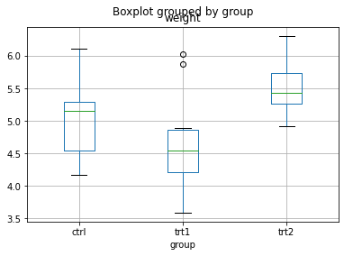

```python
#Create a boxplot
data.boxplot('weight', by='group')
```

## Normality test

```python
pg.normality(data).round(3)
```

|  | W | pval | normal |
| --- | --- | --- | --- |
| weight | 0.983 | 0.892 | True |

## ANOVA

```python
# test any differences in weight among three groups

ctrl = data[data['group'] == 'ctrl']['weight']
trt1 = data[data['group'] == 'trt1']['weight']
trt2 = data[data['group'] == 'trt2']['weight']
```

```python
# compute one-way ANOVA P value
from scipy import stats

f_val, p_val = stats.f_oneway(ctrl, trt1, trt2)

print("One-way ANOVA P =", p_val, "F value", f_val)
```

```
One-way ANOVA P = 0.0159099583256229 F value 4.846087862380136
```

```python
# ANOVA test using the python package "statsmodels"
# If this package is not installed in your machine, do "conda install statsmodels" in command prompt (Win) / terminal (Mac)
import statsmodels.api as sm
from statsmodels.formula.api import ols

mod=ols('weight ~ group', data=data).fit()

aov_table=sm.stats.anova_lm(mod)
print(aov_table)

#low p value --> significant difference exists among the groups
```

```
            df    sum_sq   mean_sq         F   PR(>F)
group      2.0   3.76634  1.883170  4.846088  0.01591
Residual  27.0  10.49209  0.388596       NaN      NaN
```

You can alos run **Post Hoc Analysis**

```python
# post hoc analysis

from statsmodels.stats.multicomp import pairwise_tukeyhsd

print(pairwise_tukeyhsd(data['weight'], data['group']))
```

```
Multiple Comparison of Means - Tukey HSD, FWER=0.05
===================================================
group1 group2 meandiff p-adj   lower  upper  reject
---------------------------------------------------
  ctrl   trt1   -0.371 0.3921 -1.0621 0.3201  False
  ctrl   trt2    0.494  0.198 -0.1971 1.1851  False
  trt1   trt2    0.865  0.012  0.1739 1.5561   True
---------------------------------------------------
```

Treatment Group #1's weight is statistically different from Treatment Group #2

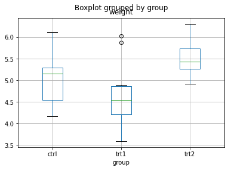

```python
#Create a boxplot
data.boxplot('weight', by='group')
```

# Appendix: using pingouin

# install pingouin https://pingouin-stats.org/ !pip install pingouin --user

```python
import pingouin as pg
```

```python
# https://github.com/raphaelvallat/pingouin/blob/master/notebooks/01_ANOVA.ipynb

df.groupby('haircolor')['painthreshold'].agg(['mean', 'std', 'count', 'var']).round(2)
```

| haircolor | mean | std | count | var |
| --- | --- | --- | --- | --- |
| Dark Blond | 51.2 | 9.28 | 5 | 86.20 |
| Dark Brunette | 37.4 | 8.32 | 5 | 69.30 |
| Light Blond | 59.2 | 8.53 | 5 | 72.70 |
| Light Brunette | 42.5 | 5.45 | 4 | 29.67 |

## T-Test & ANOVA

### Test the normality of the data

```python
display(pg.normality(df['painthreshold']))
```

|  | W | pval | normal |
| --- | --- | --- | --- |
| painthreshold | 0.971204 | 0.800256 | True |

```python
pg.normality(df, group='haircolor', dv='painthreshold')
```

|  | W | pval | normal |
| --- | --- | --- | --- |
| Light Blond | 0.991032 | 0.983182 | True |
| Dark Blond | 0.939790 | 0.664456 | True |
| Light Brunette | 0.930607 | 0.597973 | True |
| Dark Brunette | 0.883214 | 0.324129 | True |

### T-test

```python
# T-test

lb = df[df['haircolor'] == 'Light Blond']['painthreshold']
db = df[df['haircolor'] == 'Dark Blond']['painthreshold']

pg.ttest(lb, db, correction=False)
```

|  | T | dof | tail | p-val | CI95% | cohen-d | BF10 | power |
| --- | --- | --- | --- | --- | --- | --- | --- | --- |
| T-test | 1.4191 | 8 | two-sided | 0.193635 | [-5.0, 21.0] | 0.897518 | 0.875 | 0.24032 |

We can't reject the null hypothesis

### ANOVA

```python
from pingouin import anova

aov = pg.anova(data=df, dv='painthreshold', between='haircolor', detailed=True)
aov
```

|  | Source | SS | DF | MS | F | p-unc | np2 |
| --- | --- | --- | --- | --- | --- | --- | --- |
| 0 | haircolor | 1360.726316 | 3 | 453.575439 | 6.791407 | 0.004114 | 0.575962 |
| 1 | Within | 1001.800000 | 15 | 66.786667 | NaN | NaN | NaN |

The detailed ANOVA summary table includes the following columns: SS : sums of squares DF : degrees of freedom MS : mean squares (= SS / DF) F : F-value (test statistic) p-unc : uncorrected p-values np2 : partial eta-square effect size * * In one-way ANOVA, partial eta-square is the same as eta-square and generalized eta-square. In the example above, there is a main effect of group (F(3, 15) = 6.79, p = .004)), so we can reject the null hypothesis that the groups have equal means.

### Tukey post-hocs

Often, you will want to compute post-hoc tests to look at the pairwise differences between the groups. For one-way ANOVA with equal variances between groups, the optimal test is the pairwise_tukey post-hoc test.

As one can see from the post-hoc summary table below, the light blond group has a significantly higher pain threshold than the dark brunette (p=.0037) and light brunette (p=.0367) groups.

```python
pg.pairwise_tukey(data=df, dv='painthreshold', between='haircolor')
```

|  | A | B | mean(A) | mean(B) | diff | se | T | p-tukey | hedges |
| --- | --- | --- | --- | --- | --- | --- | --- | --- | --- |
| 0 | Dark Blond | Dark Brunette | 51.2 | 37.4 | 13.8 | 5.168623 | 2.669957 | 0.074168 | 1.525213 |
| 1 | Dark Blond | Light Blond | 51.2 | 59.2 | -8.0 | 5.168623 | -1.547801 | 0.436903 | -0.884182 |
| 2 | Dark Blond | Light Brunette | 51.2 | 42.5 | 8.7 | 5.482153 | 1.586968 | 0.416008 | 0.946285 |
| 3 | Dark Brunette | Light Blond | 37.4 | 59.2 | -21.8 | 5.168623 | -4.217758 | 0.003713 | -2.409395 |
| 4 | Dark Brunette | Light Brunette | 37.4 | 42.5 | -5.1 | 5.482153 | -0.930291 | 0.769703 | -0.554719 |
| 5 | Light Blond | Light Brunette | 59.2 | 42.5 | 16.7 | 5.482153 | 3.046249 | 0.036653 | 1.816432 |

### What if my groups have unequal variances? (Homogeneity of variances)

Traditional ANOVA can be quite unstable when the groups have unequal variances (see Liu 2015). Therefore, it is recommanded to use a Welch ANOVA instead, followed by Games-Howell post-hoc tests, which do not require the groups to have equal variances.

```python
#Create a boxplot
df.boxplot('painthreshold', by='haircolor')
```

[output not shown]

```python
db = df[df['haircolor'] == 'Dark Blond']['painthreshold']
dbr = df[df['haircolor'] == 'Dark Brunette']['painthreshold']
lb = df[df['haircolor'] == 'Light Blond']['painthreshold']
lbr = df[df['haircolor'] == 'Light Brunette']['painthreshold']

print(stats.levene(db, lbr))
print(stats.levene(db, dbr, lb, lbr))
```

```
LeveneResult(statistic=1.6035809906291834, pvalue=0.24590629443407336)
LeveneResult(statistic=0.39274322169059017, pvalue=0.7600161269687682)
```

Perform Levene test for equal variances.

The Levene test tests the null hypothesis that all input samples are from populations with equal variances.

https://docs.scipy.org/doc/scipy-0.14.0/reference/generated/scipy.stats.levene.html

> The above test is not significant meaning there is homogeneity of variances and you can proceed t-testing.

> **If the test were to be significant, you can use a Welch's t-test (from more than three groups) or Man Whitney U test (for two groups).**

### Non-parametric t-test

```python
# non-parametric t-test (Man Whitney U test)
# https://pingouin-stats.org/generated/pingouin.mwu.html
pg.mwu(lb, db).round(2)
```

|  | U-val | tail | p-val | RBC | CLES |
| --- | --- | --- | --- | --- | --- |
| MWU | 18.0 | two-sided | 0.3 | -0.44 | 0.72 |

```python
from scipy.stats import mannwhitneyu  #using scipy package

mannwhitneyu(lb,db, alternative='two-sided')
```

```
MannwhitneyuResult(statistic=18.0, pvalue=0.2962698714842864)
```

High p value --> We can't reject the null hypothesis

### Non-parametric ANOVA test

#### kruskal test

```python
db = df[df['haircolor'] == 'Dark Blond']['painthreshold']
dbr = df[df['haircolor'] == 'Dark Brunette']['painthreshold']
lb = df[df['haircolor'] == 'Light Blond']['painthreshold']
lbr = df[df['haircolor'] == 'Light Brunette']['painthreshold']

from scipy.stats import kruskal
stat, p = kruskal(db, dbr, lb,  lbr)
print(stat, p)
```

```
10.588630377524138 0.014171563303136903
```

#### welch test

```python
# non-parametric ANOVA test
pg.welch_anova(data=df, dv='painthreshold', between='haircolor')
```

|  | Source | ddof1 | ddof2 | F | p-unc | np2 |
| --- | --- | --- | --- | --- | --- | --- |
| 0 | haircolor | 3 | 8.329841 | 5.890115 | 0.018813 | 0.575962 |

```python
# non-parametric post hoc testing
pg.pairwise_gameshowell(data=df, dv='painthreshold', between='haircolor')
```

|  | A | B | mean(A) | mean(B) | diff | se | T | df | pval | hedges |
| --- | --- | --- | --- | --- | --- | --- | --- | --- | --- | --- |
| 0 | Dark Blond | Dark Brunette | 51.2 | 37.4 | 13.8 | 5.576737 | 2.474565 | 7.906609 | 0.140091 | 1.413596 |
| 1 | Dark Blond | Light Blond | 51.2 | 59.2 | -8.0 | 5.637375 | -1.419100 | 7.942669 | 0.521984 | -0.810661 |
| 2 | Dark Blond | Light Brunette | 51.2 | 42.5 | 8.7 | 4.965548 | 1.752072 | 6.562510 | 0.372203 | 1.044734 |
| 3 | Dark Brunette | Light Blond | 37.4 | 59.2 | -21.8 | 5.329165 | -4.090697 | 7.995416 | 0.014775 | -2.336811 |
| 4 | Dark Brunette | Light Brunette | 37.4 | 42.5 | -5.1 | 4.612664 | -1.105652 | 6.821772 | 0.684843 | -0.659283 |
| 5 | Light Blond | Light Brunette | 59.2 | 42.5 | 16.7 | 4.685794 | 3.563964 | 6.772089 | 0.037775 | 2.125137 |

# Paired t- test: Same subject

- testing differences between two variables (father's and son's heights) linked to **same subjects** (or individuals)

```python
height = pd.read_csv("data/father_son_height.csv")
height.head()
```

|  | Father | Son |
| --- | --- | --- |
| 0 | 65.0 | 59.8 |
| 1 | 63.3 | 63.2 |
| 2 | 65.0 | 63.3 |
| 3 | 65.8 | 62.8 |
| 4 | 61.1 | 64.3 |

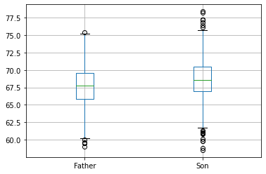

```python
height.boxplot()
```

### normality test for the same subject t-test

https://pythonfordatascience.org/paired-samples-t-test-python/

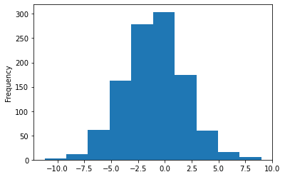

```python
height['difference'] = height['Father'] - height['Son']
height['difference'].plot(kind='hist')
```

```
((array([-3.2191808 , -2.95561487, -2.80864001, ...,  2.80864001,
          2.95561487,  3.2191808 ]),
  array([-11.2,  -9.3,  -9.3, ...,   7.4,   7.9,   9. ])),
 (2.7817405711806855, -0.9974025974025972, 0.9990451109611047))
```

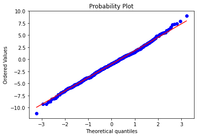

```python
stats.probplot(height['difference'], plot= plt)
```

```python
stats.shapiro(height['difference'])
```

```
ShapiroResult(statistic=0.9983996152877808, pvalue=0.4234532117843628)
```

conclusion: data is normally distributed. (high p-value 0.42 --> parametric data)

```python
stats.ttest_rel(height['Father'], height['Son'])
```

```
Ttest_relResult(statistic=-11.78631938916475, pvalue=3.0273733779822012e-30)
```

Conclusion of paired t-test: Fathers and sons have different heights.

### if the data was non-parametric ... consider a non-parametric test (e.g., Wilcoxon)

```python
results = stats.wilcoxon(height['Father'], height['Son'])
print("The t-statistic is %.3f and the p-value is %.3f." % results)
```

```
The t-statistic is 169091.000 and the p-value is 0.000.
```

Same conclusion: Fathers and sons have different heights.

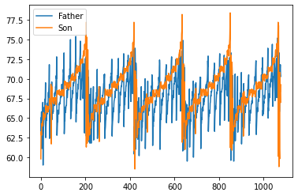

```python
#Create a plot
#plt.figure(figsize=(16,8))
plt.plot(height['Father'], label = 'Father')
plt.plot(height['Son'], label = 'Son')
plt.legend(loc='best')
```

```python
# using pingouin

pg.ttest(height['Father'], height['Son'], paired=True).round(2)
```

|  | T | dof | tail | p-val | CI95% | cohen-d | BF10 | power |
| --- | --- | --- | --- | --- | --- | --- | --- | --- |
| T-test | -11.79 | 1077 | two-sided | 0.0 | [-1.16, -0.83] | 0.36 | 6.846e+26 | 1.0 |

# References

- http://cogmaster-stats.github.io/python-cogstats/basic_statistics.html
- http://www.marsja.se/four-ways-to-conduct-one-way-anovas-using-python/#anovapy
- http://www.randalolson.com/2012/08/06/statistical-analysis-made-easy-in-python/
- http://cleverowl.uk/2015/07/01/using-one-way-anova-and-tukeys-test-to-compare-data-sets/
- https://pingouin-stats.org/generated/pingouin.ttest.html
- https://pythonfordatascience.org/paired-samples-t-test-python/